```python
#Use for hide all the code
from IPython.display import display_html
display_html("""
<div style="text-align:center; margin: 20px 0;">
<p style="color:#FA5882;text-align:center; margin: 10px 0 20px 0;">
If you don't want to see all code click here( Haoran )<br/>
Just focus on analysizing results!
</p>
<button onclick="$('.input, .prompt, .output_stderr, .output_error').toggle();">hide code</button>
<hr/>
</div>
""", raw=True)
```

If you don't want to see all code click here( Haoran )  
Just focus on analysizing results!

```python
import csv
import pandas as pd
import matplotlib.pyplot as plt
import seaborn as sns
import datetime
import time
import sys
import traceback
from math import sqrt
import csv
import datetime
import time
import sys
import traceback
from math import sqrt
import csv

GPU_FILE  = '../Data/gpu.csv'
CHECKPOINT_FILE  = '../Data/application-checkpoints.csv'
TASK_FILE  = '../Data/task-x-y.csv'
render_power = '../Data/rend_power_part.csv'
render_card = '../Data/result_card.csv'
newTask = '../Data/task_gpu.csv'
```

# Project Plan

This project contains all the request:

- One will entirely focus on EDA. This project progress will follow some CRISP-DM process, and especially focus on EDA parts,such as the data understanding,data preparation, some data analysis, data visualization, etc. Use the data we have to calculate to find some thing helpful for the render job. But if the data is too big to analysis, I will re-sample the data or only show by the smallest units.
- Another is dashboard, I will use Django to build a web application as a dashboard, but if we want the dashboard can be used dynamically and coordinatelly, it should update in the future.

# Understanding the Project for Industry and Academic Literature

#### Academic Literature

This project is almost focus entirely on EDA process.The data can be regard big data, because if we use each lines to compute, tostatistic, there are millions lines need to be processed. If we can find a moreeffective way to store it, calculate it, to visualize it and to present it, it cansave much time, furthermore, academic research can focus on the algorithm instead of processing data and constructing baseline. Academic research can be test on it directly. This is a basic stone for research.

#### Industry and Business

This project explore and analyze the knowledge behaind the data about the GPU utilization in the task of drawing and rendering by GPU. In different time，different GPU cards, different task, we can analysis the tempreture, the power, the utilization percentage. All this information, can help us dispatch and allocate the tasks and GPUs `coordinating harmonize`. After analyzing,company can make the best use of GPU, save power and increase the speed and the utilization. Also, save the cost, change the worst GPU, parallel compute are more efficient.

# Understanding the data

```python
GPU_data = pd.read_csv(GPU_FILE)
CP_data = pd.read_csv(CHECKPOINT_FILE)
XY_data = pd.read_csv(TASK_FILE)
```

```python
GPU_data.head(3)
```

|  | timestamp | hostname | gpuSerial | gpuUUID | powerDrawWatt | gpuTempC | gpuUtilPerc | gpuMemUtilPerc |
| --- | --- | --- | --- | --- | --- | --- | --- | --- |
| 0 | 2018-11-08T08:27:10.314Z | 8b6a0eebc87b4cb2b0539e81075191b900001C | 323217055910 | GPU-1d1602dc-f615-a7c7-ab53-fb4a7a479534 | 131.55 | 48 | 92 | 53 |
| 1 | 2018-11-08T08:27:10.192Z | d8241877cd994572b46c861e5d144c85000000 | 323617020295 | GPU-04a2dea7-f4f1-12d0-b94d-996446746e6f | 117.03 | 40 | 92 | 48 |
| 2 | 2018-11-08T08:27:10.842Z | db871cd77a544e13bc791a64a0c8ed50000006 | 323217056562 | GPU-f4597939-a0b4-e78a-2436-12dbab9a350f | 121.64 | 45 | 91 | 44 |

```python
GPU_data.info()
```

```
<class 'pandas.core.frame.DataFrame'>
RangeIndex: 1543681 entries, 0 to 1543680
Data columns (total 8 columns):
timestamp         1543681 non-null object
hostname          1543681 non-null object
gpuSerial         1543681 non-null int64
gpuUUID           1543681 non-null object
powerDrawWatt     1543681 non-null float64
gpuTempC          1543681 non-null int64
gpuUtilPerc       1543681 non-null int64
gpuMemUtilPerc    1543681 non-null int64
dtypes: float64(1), int64(4), object(3)
memory usage: 94.2+ MB
```

```python
CP_data.head(3)
```

|  | timestamp | hostname | eventName | eventType | jobId | taskId |
| --- | --- | --- | --- | --- | --- | --- |
| 0 | 2018-11-08T07:41:55.921Z | 0d56a730076643d585f77e00d2d8521a00000N | Tiling | STOP | 1024-lvl12-7e026be3-5fd0-48ee-b7d1-abd61f747705 | b47f0263-ba1c-48a7-8d29-4bf021b72043 |
| 1 | 2018-11-08T07:42:29.842Z | 0d56a730076643d585f77e00d2d8521a00000N | Saving Config | START | 1024-lvl12-7e026be3-5fd0-48ee-b7d1-abd61f747705 | 20fb9fcf-a927-4a4b-a64c-70258b66b42d |
| 2 | 2018-11-08T07:42:29.845Z | 0d56a730076643d585f77e00d2d8521a00000N | Saving Config | STOP | 1024-lvl12-7e026be3-5fd0-48ee-b7d1-abd61f747705 | 20fb9fcf-a927-4a4b-a64c-70258b66b42d |

```python
CP_data.info()
```

```
<class 'pandas.core.frame.DataFrame'>
RangeIndex: 660400 entries, 0 to 660399
Data columns (total 6 columns):
timestamp    660400 non-null object
hostname     660400 non-null object
eventName    660400 non-null object
eventType    660400 non-null object
jobId        660400 non-null object
taskId       660400 non-null object
dtypes: object(6)
memory usage: 30.2+ MB
```

```python
XY_data.head(3)
```

|  | taskId | jobId | x | y | level |
| --- | --- | --- | --- | --- | --- |
| 0 | 00004e77-304c-4fbd-88a1-1346ef947567 | 1024-lvl12-7e026be3-5fd0-48ee-b7d1-abd61f747705 | 116 | 178 | 12 |
| 1 | 0002afb5-d05e-4da9-bd53-7b6dc19ea6d4 | 1024-lvl12-7e026be3-5fd0-48ee-b7d1-abd61f747705 | 142 | 190 | 12 |
| 2 | 0003c380-4db9-49fb-8e1c-6f8ae466ad85 | 1024-lvl12-7e026be3-5fd0-48ee-b7d1-abd61f747705 | 142 | 86 | 12 |

```python
XY_data.info()
```

```
<class 'pandas.core.frame.DataFrame'>
RangeIndex: 65793 entries, 0 to 65792
Data columns (total 5 columns):
taskId    65793 non-null object
jobId     65793 non-null object
x         65793 non-null int64
y         65793 non-null int64
level     65793 non-null int64
dtypes: int64(3), object(2)
memory usage: 2.5+ MB
```

For this project, there are three data file we can use so far,Application, GPU, Taskfiles.The application csv file contains the information of the different renderingand drawing tasks in different stages. The GPU csv file contains the detail of using of gpu and their statements. The task csv file contains many X,Y which represent the position drawed and rendered by each task, also the render level. The jobId represnts the different job our GPU did which is splite into 3 level.

- `If you do not have enough time or very good computer, please do not do the part with long #########################################, and use the code below them.`

#### Requirements for projects, what do we need?

> EnviromentThere There are millions lines in our csv file.Considering the effi-ciency and speed of the analyzing:
> - `Ubuntu`: Linux as the local machine system.
> - `Anaconda`: Simply installed scientific analysis package for python.
> - Django: Create webapplicatin quickly and powerful

> Tools
> - `Python`: used to scientific analysis.
> - `Cookiecutteris`: used to pack the whole project as ProjectTemplate.
> - `Jupyter Notebookis`: used to make the analysis much easier to visualize, and theliterature describe can be added in smoothly.
> - `Git and Github`: used to save the project and check the changes of each time.It is easy to check the log files and cooperate with other team mates.

# Concisely, what did I do?

#### In my code, when I am converting data, if there is some dirty data, I will use condition codes to filter and drop it, such as milli_time<10000.

> - Which event types dominate task runtimes？

For each ‘eventType’, it is just the point of time, so I think we need to calculate with eventName which represent five types of tasks. I calculate the avarage time for Tiling, Saving, Config, Render, TotalRender, Uploading. The time will be STOP - START for each task, and the total render will be the sum of all the other tasks.

```python
def Get_Average(list_time):
    sum = 0
    for item in list_time:
        sum += item
    return sum/len(list_time)
```

```python
def calcTaskRuntime():
            result_dict={}
            tiling_dict = {}
            tiling_list = []
            csv_reader = csv.reader(open(CHECKPOINT_FILE))
            next(csv_reader)
            for value in csv_reader:
                if value[2] !='Tiling':
                    continue
                timestamp_str=value[0]
               	eventName=value[2]
                eventType=value[3]
                taskId=value[5]
                timestamp_str=timestamp_str.replace('T',' ')
                timestamp_str=timestamp_str.replace('Z','')
                timestamp_str=timestamp_str.replace('"','')
                timestamp_str.strip()
                struct_time=time.strptime(str(timestamp_str), "%Y-%m-%d %H:%M:%S.%f")
                milli_time=time.mktime(struct_time)
                if milli_time < 1000:
                    continue
                if taskId in tiling_dict:
                    timestamp = tiling_dict[taskId]
                    total_time = abs(float(timestamp) - float(milli_time))
                    tiling_dict[taskId]=total_time
                    if total_time < 1000:
                        tiling_list.append(total_time)
                else:
                    tiling_dict[taskId] = milli_time
            ret = Get_Average(tiling_list)
            result_dict['tiling'] = ret


            #query saving config
            saving_config_dict = {}
            saving_config_list = []
            csv_reader = csv.reader(open(CHECKPOINT_FILE))
            next(csv_reader)
            for value in csv_reader:
                if value[2]!='Saving Config':
                    continue
                timestamp_str   = value[0]
                eventName = value[2]
                eventType = value[3]
                taskId    = value[5]
                timestamp_str = timestamp_str.replace('T',' ')
                timestamp_str = timestamp_str.replace('Z','')
                timestamp_str = timestamp_str.replace('"','')
                struct_time = time.strptime(timestamp_str, "%Y-%m-%d %H:%M:%S.%f")
                milli_time = time.mktime(struct_time)
                if milli_time < 1000:
                    continue
                if taskId in saving_config_dict:
                    timestamp = saving_config_dict[taskId]
                    total_time = abs(float(timestamp) - float(milli_time))
                    saving_config_list.append(total_time)
                else:
                    saving_config_dict[taskId] = milli_time
            result_dict['saving_config'] = Get_Average(saving_config_list)
            render_dict = {}
            render_list = []
            csv_reader = csv.reader(open(CHECKPOINT_FILE))
            next(csv_reader)
            for value in csv_reader:
                if value[2]!='Render':
                    continue
                timestamp_str   = value[0]
                eventName = value[2]
                eventType = value[3]
                taskId    = value[5]
                timestamp_str = timestamp_str.replace('T',' ')
                timestamp_str = timestamp_str.replace('Z','')
                timestamp_str = timestamp_str.replace('"','')
                struct_time = time.strptime(timestamp_str, "%Y-%m-%d %H:%M:%S.%f")
                milli_time = time.mktime(struct_time)
                if milli_time < 1000:
                    continue
                if taskId in render_dict:
                    timestamp = render_dict[taskId]
                    total_time = abs(float(timestamp) - float(milli_time))
                    render_dict[taskId] = total_time
                    if total_time < 10000:
                    	render_list.append(total_time)
                else:
                    render_dict[taskId] = milli_time
            result_dict['render'] = Get_Average(render_list)
            uploading_dict = {}
            uploading_list = []
            csv_reader = csv.reader(open(CHECKPOINT_FILE))
            next(csv_reader)
            for value in csv_reader:
                if value[2]!='Uploading':
                    continue
                timestamp_str   = value[0]
                eventName = value[2]
                eventType = value[3]
                taskId    = value[5]
                timestamp_str = timestamp_str.replace('T',' ')
                timestamp_str = timestamp_str.replace('Z','')
                timestamp_str = timestamp_str.replace('"','')
                struct_time = time.strptime(timestamp_str, "%Y-%m-%d %H:%M:%S.%f")
                milli_time = time.mktime(struct_time)
                if milli_time < 1000:
                    continue
                if taskId in uploading_dict:
                    timestamp = uploading_dict[taskId]
                    total_time = abs(float(timestamp) - float(milli_time))
                    uploading_dict[taskId] = total_time
                    if total_time < 1000:
                        uploading_list.append(total_time)
                else:
                    uploading_dict[taskId] = milli_time
            result_dict['uploading'] = Get_Average(uploading_list)
            print (result_dict)

            return result_dict
```

```python
result_dict = calcTaskRuntime()
```

```
{'tiling': 0.9709872804360994, 'saving_config': 0.0024740899422209485, 'render': 41.11676256814052, 'uploading': 1.390717746820109}
```

```
Total Render will be: 43.480941685338955
```

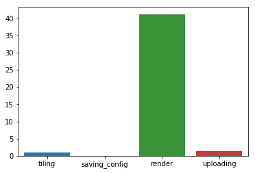

```python
name = []
value = []

for i in result_dict:
    name.append(i)
    value.append(result_dict[i])

print('Total Render will be:', sum(value))
sns.barplot(name,value)
```

#### So, as we can see, in average, that the 'render' event dominate the most time of the each task and the TotalRender time is the sum of all events. This is reasonable, because the main event is 'render', we need to render our Terascope. Other operation is just a pre process and later operation.

> - What is the interplay between GPU temperature and performance?

The performance of GPU can be measured by power, GPU cores and GPU memory utilization. We can analysis the relationship between the temperature and them.

```python
data = pd.read_csv(GPU_FILE)
data.sort_values('gpuTempC',ascending=False)
data_cor = data.corr()
data_cor.style.background_gradient()
```

|  | gpuSerial | powerDrawWatt | gpuTempC | gpuUtilPerc | gpuMemUtilPerc |
| --- | --- | --- | --- | --- | --- |
| gpuSerial | 1 | -0.0130078 | -0.142388 | 0.00145148 | 0.0046463 |
| powerDrawWatt | -0.0130078 | 1 | 0.537191 | 0.862673 | 0.870745 |
| gpuTempC | -0.142388 | 0.537191 | 1 | 0.505906 | 0.492783 |
| gpuUtilPerc | 0.00145148 | 0.862673 | 0.505906 | 1 | 0.966571 |
| gpuMemUtilPerc | 0.0046463 | 0.870745 | 0.492783 | 0.966571 | 1 |

First, we can check the correlation of them.

As we can see that the highest correlation of GPU tempreture is the powerDraw, and the serial of GPU can not affect the gpu temperature much.

So how can we measure the performance of GPU ? First, we should check the correlation matrix from last cell, the power, the Cores and the Memories, they all had very high positive relationship with each other. So we can assess the performance of the GPU by average of them or each of them, or total of them. Because GPU need them to perform better. I choose to check them one by one. And also, I use gpu temperature as the x-axis instead of making it as y-axis for conviniently checking the temperature in both `render using gpu` and `not render gpu`.

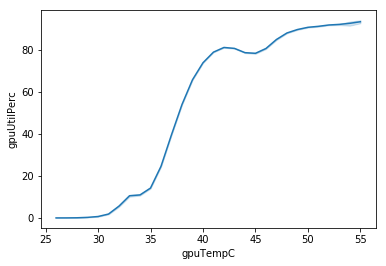

```python
sns.lineplot(data['gpuTempC'], data['gpuUtilPerc'])
```

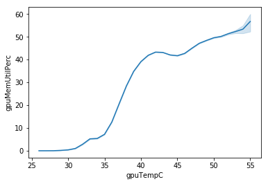

```python
sns.lineplot(data['gpuTempC'], data['gpuMemUtilPerc'])
```

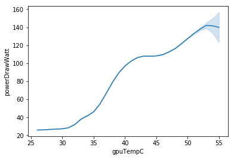

```python
sns.lineplot(data['gpuTempC'], data['powerDrawWatt'])
```

> - What is the interplay between increased power draw and render time?

Based on the first part, it calculate the average task time for five events. In this part, I will only use the render time, and the time range betwe STOP and START. And I use the `hostname` to combine the checkpoint file and GPU file in order to get the render time vs powerDraw. The 1024 hostname represents the 1024 GPUs, and for quickly get well known of the powerDraw and render time, I will extract one GPU to check the interplay. It is reasonable, in real industry application, we can set a interface show all the GPU performance automatically or use a choice button to choose any GPU to check. And also I sampled from the first 200 lines data to increase the speed.

```python
#############################careful it will cost huge time######################################################
# if you want to run it, remove the code with @@
# or you can try next cell firstly thank you
def calcRendAndPower():
    total_render_dict = {}
    total_render_list = []
    rend_power = []
    csv_reader = csv.reader(open(CHECKPOINT_FILE))
    next(csv_reader)
    # @@ out = open('rend_power_part.csv','a')
    # @@ csv_write = csv.writer(out,dialect='excel')
    start_row=1
    for value in csv_reader:
        timestamp_str   = value[0]
        hostname = value[1]
        eventName = value[2]
        eventType = value[3]
        taskId    = value[5]
        timestamp_str = timestamp_str.replace('T',' ')
        timestamp_str = timestamp_str.replace('Z','')
        timestamp_str = timestamp_str.replace('"','')
        struct_time = time.strptime(timestamp_str, "%Y-%m-%d %H:%M:%S.%f")
        milli_time = time.mktime(struct_time)

        if milli_time < 1000:
            continue
        if taskId in total_render_dict:
            times_dict= total_render_dict[taskId]
            time_start_stamp = times_dict.get("START",None)
            time_stop_stamp  = times_dict.get("STOP",None)
            if time_start_stamp is None:
                times_dict['START'] = milli_time
            else:
                times_dict['STOP'] = milli_time
            times_dict['HOSTNAME'] = hostname
            total_render_dict[taskId] = times_dict
            start_time = times_dict['START']
            end_time   = times_dict['STOP']
            rend_power_sub = []
            rend_power_time_sub=[]
            csv_reader = csv.reader(open(GPU_FILE))
            next(csv_reader)
            mill_time={}
            for value in csv_reader:
                if value[1] !=hostname:
                    continue
                timestamp_str   = value[0]
                write_time = timestamp_str
                powerdrawwatt   = value[4]
                timestamp_str = timestamp_str.replace('T',' ')
                timestamp_str = timestamp_str.replace('Z','')
                timestamp_str = timestamp_str.replace('"','')
                struct_time = time.strptime(timestamp_str, "%Y-%m-%d %H:%M:%S.%f")
                milli_time = time.mktime(struct_time)
                if milli_time<=end_time and milli_time >= start_time:
                    mill_time[milli_time]=timestamp_str
                    rend_power_sub.append(powerdrawwatt)
                    #rend_power_time_sub.append(timestamp_str)
                #print rend_power_sub
            new=sorted(mill_time)
            write_time = mill_time.values()
            start_row=start_row+1
            if start_row >=200:
                break
            if len(write_time)<=5 or len(rend_power_sub) <=5:
                continue
            csv_write.writerow(write_time)
            csv_write.writerow(rend_power_sub)
                #rend_power.append(rend_power_sub)
        else:
            time_dict={}
            if eventType == '"START"':
                time_dict['START'] = milli_time
            else:
                time_dict['STOP'] = milli_time
                total_render_dict[taskId] = time_dict
```

```python
data = pd.read_csv(render_power)
d = data.transpose()
d = d.sort_values(by=5)
x = list(d[5])
y1 = list(d[6])
y = []
for i in y1:
    y.append(float(i))
da = {'time': x, 'Power': y}
data2 = pd.DataFrame(data=da)
data2.head()
```

|  | time | Power |
| --- | --- | --- |
| 0 | 2018-11-08 08:14:06.105 | 42.96 |
| 1 | 2018-11-08 08:14:08.122 | 42.93 |
| 2 | 2018-11-08 08:14:10.139 | 42.94 |
| 3 | 2018-11-08 08:14:12.155 | 42.85 |
| 4 | 2018-11-08 08:14:14.173 | 135.47 |

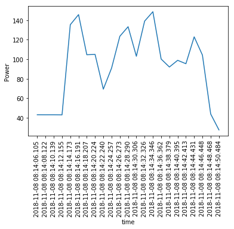

```python
g = sns.lineplot(data2['time'],data2['Power'])
plt.setp(g.get_xticklabels(), rotation=90)
plt.show()
```

> - Can we identify particular GPU cards (based on their serial numbers) whose performance differs to other cards? (i.e. perpetually slow cards).

###### The first issue we need to deal is how can we measure the speed of our GPU? Well, first of all, we should compare it in same job and task. It is not fair if we compare the GPU cards doing the different job or task. So 3 jobs map the three levels, and they contains many many tasks, and in each tasks, it contains some GPU. But for same gpu they will influenced by temperature or differentces in 'version 2' and 'version2.1'. So I calculate the STOP - START time by tasks. Keep the same job, calculate how much time will the different tasks( represent GPU cards) cost. And more time means slower speed the GPU cards in that task, because they do the same level(job) of render.

```python
#############################careful it will cost huge time######################################################
def identifyParticularGpu():
    #query total render
    gpu_rendtime={}
    total_render_dict = {}
    total_render_list = []
    rend_power = []
    csv_reader = csv.reader(open(CHECKPOINT_FILE))
    next(csv_reader)
    task_rendtime={}
    #out = open('rend_power_part.csv','a')
    #csv_write = csv.writer(out,dialect='excel')
    start_row=1
    for value in csv_reader:
        if start_row >=100:
                break
        timestamp_str   = value[0]
        hostname = value[1]
        eventName = value[2]
        eventType = value[3]
        taskId    = value[5]
        timestamp_str = timestamp_str.replace('T',' ')
        timestamp_str = timestamp_str.replace('Z','')
        timestamp_str = timestamp_str.replace('"','')
        struct_time = time.strptime(timestamp_str, "%Y-%m-%d %H:%M:%S.%f")
        milli_time = time.mktime(struct_time)

        if milli_time < 1000:
            continue
        if taskId in total_render_dict:
            times_dict= total_render_dict[taskId]
            time_start_stamp = times_dict.get("START",None)
            time_stop_stamp  = times_dict.get("STOP",None)
            if time_start_stamp is None:
                times_dict['START'] = milli_time
            else:
                times_dict['STOP'] = milli_time
            #times_dict['HOSTNAME'] = hostname
            total_render_dict[taskId] = times_dict
            start_time = times_dict['START']
            end_time   = times_dict['STOP']

            render_info = {}
            render_info['rendtimer'] = end_time-start_time
            if end_time-start_time <= 30:
                continue
            gpu_rendtime[taskId]=render_info
            csv_reader = csv.reader(open(TASK_FILE))
            next(csv_reader)
            for value in csv_reader:
                if value[4] != '4':
                    continue
                taskId = value[0]
                if taskId in gpu_rendtime:
                    render_info = gpu_rendtime[taskId]
                    render_info['x'] = value[2]
                    render_info['y'] = value[3]
                    render_info['level']=value[4]
                    gpu_rendtime[taskId] = render_info
        else:
            time_dict={}
            if eventType == '"START"':
                time_dict['START'] = milli_time
            else:
                time_dict['STOP'] = milli_time

                total_render_dict[taskId] = time_dict
        #print gpu_rendtime
    print (gpu_rendtime.values())
    return gpu_rendtime
```

##### The render time were obtained from each gpu in differnet task, all the tasks are included in 3 jobs which represnt the levels. And after getting the render time, I generate the new task.csv file with render rime.

```python
##This cell is connected with two cell above,so you do not need to run it unless you runned the two cells above
# If you successfully run the code above Remove the code with @@ and run this cell
extract = identifyParticularGpu()
taskid = []
task_time = []
x = []
y = []
level = []

for j in extract:
    taskid.append(j)
    task_time.append(a[j]['rendtimer'])
data3 = pd.read_csv(taskxy)
for k in taskid:
    x.append(int(data3[data3['taskId']==k]['x']))
    y.append(int(data3[data3['taskId']==k]['y']))
    level.append(int(data3[data3['taskId']==k]['level']))
newda = {'taskId':taskid,'x':x,'y':y,
          'level':level,'render_time':task_time}

newData = pd.DataFrame(data=newda)
# @@ newData.to_csv(newTask)
newData.head()
```

[output not shown]

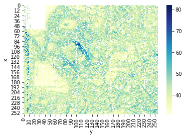

```python
new = pd.read_csv(newTask)

new = new[new['level']==12]

newFrame = new.pivot('x','y','render_time')

sns.heatmap(newFrame, cmap="YlGnBu")
```

##### It is very clear in this graph to identify the slow gpu and the fast gpu by the render time. This graph is based on x-y comes from TeraScope needed to be rendered. So we can directly check which part the GPU is slow which part is fast.( It is the TeraScope map, just different colors) The center Statium need is the slowest

# The last step is type this address into your browser to check the dashboard:

> http://104.196.205.71:8088/

# Discussion and Future

- For the one part, The results from the data are credible, cause it based on millions of situations, we can find some rules and regular things from the EDA process, we can define the persormance and use the visualization to check. Further more, I think we can create some website for keep monitoring the performance of each task and each GPU automatically. So the `Not Enough Data` will not be the problem, and the engineer can adjust the tasks and GPUS. And when I am check the data and prepared for analyzing, I find that the collection of the data can be more intensive, which can measure the persormance better.The final thing but most important thing I want to mention is that although the data is not much big enough, but it takes me much time in point3 and point4, so I think we can transfer all the process into big data enviroment, such as Hadoop,and use Hive and HBase, because time are money too.
- For another dashboard part, I think the way of dataloader and coordinate can be more efficient, and then it will performance like a dynamical monitor for our Render project. Engineer can easily control the eviroment of the render.
- The common thing is we can use hadoop in both phase:analysis and store data by stream.

# Self Learning from Project

During the project, the most valuable experience is the whole process of EDAand data analyzing, they lead me to think. Think about the mining of data, and how to connect the data mining to our problem, think how can we use thisdata,and think whether the results is reasonable and the value of the results.Also, this project strengthen my coding ability and experience of data science. Also, this is the first time I combine the analysis with dashboard application, I find it is very useful and necessary to have a dashboard in data science, which make everyone can understand and use it directly.